# NUS Data Analytics Competition 2022

### Analysis of Grab-Posisi Dataset

[Source](https://engineering.grab.com/grab-posisi)

##### Prepared by:

Alif Naufal Farrashady

Chua Yee Siong Danyel

Chng Jin Yang Ray

### Problem Statement

There has been feedback about delays in Grab transport services in both Jakarta and Singapore (late driver arrival → late arrival at destination). This has led to a decrease in customer satisfaction and trust, which might increase customer turnover. Upon further research, it was found that this could be due to inaccurate ETA prediction, bad route planning, or other factors. Using the above dataset of GPS pings, what insights can your team obtain to help Grab alleviate these issues?

### 1. Data Cleansing & Transformation

Firstly, we start by importing the necessary packages and setting our directory location.

```python
import numpy as np
import scipy as sp
import pandas as pd
import statsmodels.formula.api as ssf
import statsmodels.api as sm
import os
from datetime import datetime, date
import folium
from folium import plugins
from branca.element import Figure
from math import radians, cos, sin, asin, sqrt

# Change according to the location of your datasets
sg_directory = r'C:\Users\alif8\Documents\NUS\Case Competitions\NUS Data Analytics Competition 2022\grab-posis-city=Singapore\city=Singapore'
jkt_directory = r'C:\Users\alif8\Documents\NUS\Case Competitions\NUS Data Analytics Competition 2022\grab-posis-city=Jakarta\city=Jakarta'

# Latitude & Longitude of Singapore
sg_lat = 1.290270
sg_lng = 103.851959
# Latitude & Longitude of Jakarta
jkt_lat = -6.2088
jkt_lng = 106.8456
```

Next, we set up the helper functions that will help us use more memory-efficient datatypes and build datetime columns to aid in our analysis.

```python
# Note: Code was obtained from NUS SDS Workshop

def to_category(df, *args):
    for col_name in args:
        df[col_name] = df[col_name].astype("category")

def to_float32(df, *args):
    for col_name in args:
        df[col_name] = df[col_name].astype("float32")

def to_uint16(df, *args):
    for col_name in args:
        df[col_name] = df[col_name].astype("uint16")

def to_int32(df, *args):
    for col_name in args:
      df[col_name] = df[col_name].astype("int32")

def format_datetime(df, col_name):
    # Get datetime obj for all timestamps
    dt = df[col_name].apply(datetime.fromtimestamp)

    df["time"] = dt.apply(lambda x: x.time())
    df["hour"] = dt.apply(lambda x: x.hour)
    df["day_of_week"] = dt.apply(lambda x: x.weekday())
    df["month"] = dt.apply(lambda x: x.month)
    df["year"] = dt.apply(lambda x: x.year)
```

We then combined all the datasets into one large Pandas DataFrame. Initially, when exploring and testing out various approaches to the dataset, we used only a single parquet file in order to reduce processing time.

```python
# Merges all dataset into one DataFrame, take note it will have a long runtime
# Input is either sg_directory or jkt_directory
def file_combine(directory):
    dataset = []
    for filename in os.listdir(directory):
        if filename.endswith(".parquet"):
            next_df = pd.read_parquet(directory + r'/' + filename)
            # Alternative configuration to filter by car/motorcycle for Jakarta dataset
            #next_df =pd.read_parquet(directory + r'/' + filename,  filters=[('driving_mode','=','car')])
            dataset.append(next_df)
    return pd.concat(dataset, axis=0, ignore_index=True)

df = file_combine(sg_directory)

df_sample = pd.read_parquet(sg_directory + r'/' + 'part-00000-8bbff892-97d2-4011-9961-703e38972569.c000.snappy.parquet')

# Can change line below to df_fixed = df_sample.copy() to replicate analysis with the sample instead
df_fixed = df.copy()
format_datetime(df_fixed, "pingtimestamp")
to_category(df_fixed, ["trj_id", "driving_mode", "osname"])
to_float32(df_fixed, ["rawlat", "rawlng", "speed", "accuracy"])
to_uint16(df_fixed, ["bearing", "day_of_week", "month", "year"])
to_int32(df_fixed, "pingtimestamp")
df_fixed.info()
```

```
<class 'pandas.core.frame.DataFrame'>
RangeIndex: 30329685 entries, 0 to 30329684
Data columns (total 14 columns):
 #   Column         Dtype
---  ------         -----
 0   trj_id         category
 1   driving_mode   category
 2   osname         category
 3   pingtimestamp  int32
 4   rawlat         float32
 5   rawlng         float32
 6   speed          float32
 7   bearing        uint16
 8   accuracy       float32
 9   time           object
 10  hour           int64
 11  day_of_week    uint16
 12  month          uint16
 13  year           uint16
dtypes: category(3), float32(4), int32(1), int64(1), object(1), uint16(4)
memory usage: 1.4+ GB
```

### 2. Exploratory Data Analysis

Firstly, we wanted to understand how many unique trips there were.

```python
len(df_fixed['trj_id'].unique())
```

```
28000
```

Next, we used the groupby function in Pandas to aggregate the dataset, where each unique trip occupies only one row. We added in columns to capture the start points (start_lat , start_lng), end points (end_lat, end_lng) as well as the average speed that the trip took.

This was done as our approach was to compare trips with similar start and end points and see if their routes would differ.

```python
start_points = df_fixed.groupby(['trj_id'])['time'].transform(min) == df_fixed['time']
start_points
df_start = df_fixed.loc[start_points].copy()

df_start.rename(columns={
    'rawlat': 'start_lat',
    'rawlng': 'start_lng'}, inplace=True)

end_points = df_fixed.groupby(['trj_id'])['time'].transform(max) == df_fixed['time']
df_end = df_fixed.loc[end_points].copy()
df_end = df_end[['trj_id', 'rawlat', 'rawlng']]
print(df_end)
df_end.rename(columns={
    'rawlat': 'end_lat',
    'rawlng': 'end_lng'}, inplace=True)

df_end_time = df_fixed.loc[end_points].copy()
df_end_time = df_end_time[['trj_id', 'time']]
df_end_time.rename(columns = {
    'time': 'end_time'}, inplace=True)

print(df_end_time)

mean_speeds = df_fixed.groupby(['trj_id']).agg(
    mean_speed = pd.NamedAgg(column='speed', aggfunc=lambda x: sum(x) / len(x)))

df_start_end = pd.merge(df_start, df_end, how='left', on='trj_id')
df_start_end = pd.merge(df_start_end, df_end_time, how='left', on='trj_id')
df_start_end = pd.merge(df_start_end, mean_speeds, how='left', on='trj_id')
```

```
         trj_id    rawlat      rawlng
1262       3671  1.299857  103.855202
2553      65747  1.375112  103.875252
4314      83162  1.329180  103.841675
8421      75831  1.392944  103.904289
9120      29097  1.281594  103.860527
...         ...       ...         ...
30323879  59810  1.431720  103.769547
30325290  71537  1.327284  103.841484
30326220  73362  1.355363  103.736534
30328387  63513  1.342762  103.746452
30329180  53168  1.343377  103.838226

[28000 rows x 3 columns]
         trj_id  end_time
1262       3671  11:14:17
2553      65747  20:32:32
4314      83162  09:37:58
8421      75831  19:44:55
9120      29097  09:40:41
...         ...       ...
30323879  59810  01:14:54
30325290  71537  09:47:42
30326220  73362  07:30:28
30328387  63513  08:48:01
30329180  53168  12:51:41

[28000 rows x 2 columns]
```

Subsequently, we constructed a custom Trip object class that stores certain key attributes, as a helper for us to calculate the distances between points later on.

```python
class Trip:
    def __init__(self, trj_id, start_lat, start_lng, end_lat, end_lng, mean_speed):
        self.trj_id = trj_id
        self.start_lat = start_lat
        self.start_lng = start_lng
        self.end_lat = end_lat
        self.end_lng = end_lng
        self.mean_speed = mean_speed

    def check(self):
        return "test"

def trip_constructor(row):
    return Trip(row['trj_id'], row['start_lat'], row['start_lng'], row['end_lat'], row['end_lng'], row['mean_speed'])

df_start_end['trip_obj'] = df_start_end.apply(lambda row: trip_constructor(row), axis=1)
```

We also set up additional helper functions.

The first helper function calculates distance between points via latitude & longitude, using the Haversine formula.

The second helper function is a boolean function that uses the first helper funciton to check if two trip objects have start and end points that are within 0.1km of each other.

```python
def distance(lat1, lat2, lon1, lon2):

    # The math module contains a function named radians which converts from degrees to radians.
    lon1 = radians(lon1)
    lon2 = radians(lon2)
    lat1 = radians(lat1)
    lat2 = radians(lat2)

    # Haversine formula
    dlon = lon2 - lon1
    dlat = lat2 - lat1
    a = sin(dlat / 2)**2 + cos(lat1) * cos(lat2) * sin(dlon / 2)**2

    c = 2 * asin(sqrt(a))

    # Radius of earth in kilometers. Use 3956 for miles
    r = 6371

    # calculate the result
    return(c * r)

def same_start_end(trip1, trip2):
    # Threshold(in km) can be adjusted as needed
    threshold = 0.1
    start_same = abs(distance(
        trip1.start_lat,
        trip2.start_lat,
        trip1.start_lng,
        trip2.start_lng)) <= threshold
    end_same = abs(distance(
        trip1.end_lat,
        trip2.end_lat,
        trip1.end_lng,
        trip2.end_lng)) <= threshold
    return start_same and end_same
```

As mentioned earlier, we want to look for pairs of trips with similar start and end points, in order to observe the routes taken.

At this point, we can select the time of the day we want to draw our pairs of trips from, based on their trip start hour.

```python
# Select time of day to draw pairs of trips from
hours = [10,]
df_sample_sample = df_start_end[df_start_end.hour.isin(hours)]
trip_array = df_sample_sample['trip_obj'].to_list()

comparable_trips = []

for i in range(len(trip_array)):
    for j in range(i, len(trip_array)):
        if trip_array[i] != trip_array[j]:
            if same_start_end(trip_array[i], trip_array[j]):
                comparable_trips += [[trip_array[i], trip_array[j]]]

comparable_trips_id = list(map(lambda x: [x[0].trj_id, x[1].trj_id], comparable_trips))
comparable_trips_id

# Notable points that we have found:
# 17hrs [0]
# 8hrs [10]
# 10 hrs [0]
```

```
[['79033', '67609'], ['28599', '68684'], ['1423', '76740'], ['49137', '79675']]
```

From the above pairs of trips, we can select a pair and observe the routes taken.

```python
# Select test pair here
test_pair = comparable_trips_id[1]
# Alternatively, if there any two trips we want to manually, compare, can also set test_pair to the respective ids of those trips
#test_pair = ['59076','76917']
test_1 = test_pair[0]
test_2 = test_pair[1]

df_test = df_start_end['trj_id'].isin([test_1, test_2])
df_start_end[df_test]
df_first_col = df_start_end[df_test].head(1)
```

Now we would like to plot the routes these our selected pair of trips took. First we will set up some helper functions to aid in our analysis.

```python
# Note: Code for first 2 functions was obtained from NUS SDS Workshop

def get_route(df, trj_id):
    return df.query('trj_id == ' + f"'{trj_id}'").sort_values("pingtimestamp")[["rawlat", "rawlng"]]

def get_start_end_pos(trj):
  return (trj.iloc[0, :], trj.iloc[-1, :])

def get_mean_speed(df, trj_id):
  return round(df.query('trj_id == ' + f"'{trj_id}'")['mean_speed'].values[0], 2)
```

Now, we are ready to plot the routes of our pair of trips.

We repeated this process with multiple pairs to observe if there were any strange routes or anomalies. We did realise that during peak periods, the routes taken can be very inconsistent.

```python
route_1 = get_route(df_fixed, test_1)
route_2 = get_route(df_fixed, test_2)
route_1_mean_speed = get_mean_speed(df_start_end, test_1)
route_2_mean_speed = get_mean_speed(df_start_end, test_2)

info_1 = f"ID: {test_1}\nAvg Speed: {route_1_mean_speed}"
info_2 = f"ID: {test_2}\nAvg Speed: {route_2_mean_speed}"

fig_trj = Figure(height = 550, width = 750)

m_trj = folium.Map(location = [sg_lat, sg_lng],
                tiles = 'cartodbpositron', zoom_start = 11,
                min_zoom = 11, max_zoom = 18)
fig_trj.add_child(m_trj)

f1 = folium.FeatureGroup(f"{test_1}")
f2 = folium.FeatureGroup(f"{test_2}")

line_1 = folium.vector_layers.PolyLine(route_1.values,
                                       popup = '<b>Path of Vehicle_1</b>',
                                       tooltip = f"{info_1}",
                                       color = 'blue', weight = 1).add_to(f1)
line_2 = folium.vector_layers.PolyLine(route_2.values,
                                       popup = '<b>Path of Vehicle_2</b>',
                                       tooltip = f"{info_2}",
                                       color = 'red', weight = 1).add_to(f2)
f1.add_to(m_trj)
f2.add_to(m_trj)

route_1_positions = get_start_end_pos(route_1)
route_2_positions = get_start_end_pos(route_2)

folium.Marker(
    location = [route_1_positions[1][0], route_1_positions[1][1]],
    popup = f"{info_1}",
    icon = folium.Icon(color = "blue"),
).add_to(f1)

folium.Marker(
    location = [route_2_positions[0][0], route_2_positions[0][1]],
    popup = f"{info_2}",
    icon = folium.Icon(color = "red"),
).add_to(f2)

folium.LayerControl().add_to(m_trj)

m_trj
```

[interactive chart not shown]

### 3. Visualisation

Having found that the routes recommended for trips with similar start and end points can be very different, we decided to further investigate this phenomenon, using selected popular destinations and residential areas of Singapore.

We then collected all the trips that started and ended near our chosen start and end points.

```python
# Threshold represents the radius (in km) around the selected destination to collect trips from
threshold = 2

# Coordinates of selected destinations and areas
# Singapore
cck = [1.3840, 103.7470]
orchard = [1.3048, 103.8318]
nus = [1.2966, 103.7764]
changi_airport = [1.3644, 103.9915]
city_hall = [1.2931, 103.8520]
bukit_panjang = [1.3774, 103.7719]
amk = [1.3691, 103.8454]

# Jakarta
menteng_CBD = [-6.1960, 106.8331]
jkt_airport = [-6.1271, 106.6535]
kemang_village = [-6.2778, 106.8114]
gambir = [-6.1703, 106.8148]
grand_indonesia_mall = [-6.1952, 106.8204]

# Represented as [start, end]
test_pair_start = [amk, city_hall]

# Helper functions to find similar start and end points
def helper_start(a,b,c):
    return distance(a['start_lat'],b,a['start_lng'],c)
def helper_end(a,b,c):
    return distance(a['end_lat'],b,a['end_lng'],c)

travel_time = df_start_end.apply(lambda x: datetime.combine(date.min, x['end_time']) -
                                 datetime.combine(date.min, x['time']), axis = 1)

boolean_start = df_start_end.apply(lambda x: helper_start(x,test_pair_start[0][0],
                                         test_pair_start[0][1]) < threshold, axis = 1)
boolean_end = df_start_end.apply(lambda x: helper_end(x,test_pair_start[1][0],
                                         test_pair_start[1][1]) < threshold, axis = 1)
travel_time.name = 'travel_time'
boolean_start.name = 'start_bool'
boolean_end.name = 'end_bool'
result = pd.concat([df_start_end, travel_time], axis=1)
result = pd.concat([result, boolean_start], axis=1)
result = pd.concat([result, boolean_end], axis=1)
result_filtered = result[result.start_bool & result.end_bool]
result_filtered.head(5)
```

|  | trj_id | driving_mode | osname | pingtimestamp | start_lat | start_lng | speed | bearing | accuracy | time | ... | month | year | end_lat | end_lng | end_time | mean_speed | trip_obj | travel_time | start_bool | end_bool |
| --- | --- | --- | --- | --- | --- | --- | --- | --- | --- | --- | --- | --- | --- | --- | --- | --- | --- | --- | --- | --- | --- |
| 118 | 79954 | car | ios | 1554860420 | 1.376810 | 103.847389 | 1.190000 | 109 | 5.000 | 09:40:20 | ... | 4 | 2019 | 1.301427 | 103.842964 | 09:58:37 | 10.439263 | <__main__.Trip object at 0x0000019E76B78490> | 0 days 00:18:17 | True | True |
| 1795 | 77812 | car | android | 1554938856 | 1.375896 | 103.856216 | 14.306968 | 80 | 4.842 | 07:27:36 | ... | 4 | 2019 | 1.285942 | 103.861633 | 07:45:28 | 11.585155 | <__main__.Trip object at 0x0000019EC45B0C10> | 0 days 00:17:52 | True | True |
| 2041 | 59247 | car | ios | 1554768550 | 1.360194 | 103.843506 | 1.820000 | 310 | 10.000 | 08:09:10 | ... | 4 | 2019 | 1.294737 | 103.844154 | 08:27:58 | 10.215965 | <__main__.Trip object at 0x0000019EC3C1BAF0> | 0 days 00:18:48 | True | True |
| 2191 | 76917 | car | android | 1555581245 | 1.362472 | 103.856041 | 8.320000 | 170 | 50.000 | 17:54:05 | ... | 4 | 2019 | 1.278994 | 103.859413 | 18:23:14 | 5.865573 | <__main__.Trip object at 0x0000019EC2E11790> | 0 days 00:29:09 | True | True |
| 2534 | 46166 | car | android | 1555291918 | 1.376211 | 103.834267 | 4.311130 | 230 | 4.000 | 09:31:58 | ... | 4 | 2019 | 1.309097 | 103.846489 | 09:52:05 | 10.304956 | <__main__.Trip object at 0x0000019EC2AA98E0> | 0 days 00:20:07 | True | True |

5 rows × 22 columns

We decided the best way to visualise this information was through HeatMaps. Since we had access to the start time of the trips, we generated both HeatMaps and HeatMapsWithTime to visualise how the routes differed.

In order to this, we collected the full routes of all the trips that we collated above.

```python
# List of lists of lists, where the outermost list represents trip start hour and the innermost list represents the coordinates of a ping
time_pings = [[] for i in range(0, 24)]
# List of lists, where each inner list represents the coordinates of a ping
nontime_pings = []

# Helper function that adds to both time_pings and nontime_pings simultaneously
def add_pings(row):
    trj_id_key = row['trj_id']
    hours = row['hour']
    global time_pings
    global nontime_pings
    time_pings[hours] += get_route(df_fixed, trj_id_key).values.tolist()
    nontime_pings += get_route(df_fixed, trj_id_key).values.tolist()

result_filtered.apply(lambda row: add_pings(row), axis=1)
```

```
118      None
1795     None
2041     None
2191     None
2534     None
3352     None
3516     None
4932     None
5412     None
5817     None
5918     None
6612     None
6674     None
8498     None
8550     None
```

[output cut: 37 more lines]

Now, we plot the HeatMap.

```python
# Gradient of HeatMap
gradient = {'0':'Navy', '0.25':'Blue','0.5':'Green', '0.75':'Yellow','1': 'Red'}
# Alternative gradient setting
# gradient={.2:'Yellow', .5:'Green', .75: 'Pink',1: 'Yellow'}

fig_heatmap = Figure(height = 550, width = 750)

# Creating map
map_heatmap = folium.Map([sg_lat, sg_lng], zoom_start = 11,
                             min_zoom = 11, max_zoom = 16)
fig_heatmap.add_child(map_heatmap)

# Creating HeatMap
plugins.HeatMap(nontime_pings, radius = 4, blur = 5, gradient=gradient).add_to(map_heatmap)

map_heatmap
```

[interactive chart not shown]

Lastly, we plot the HeatMapWithTime.

```python
fig_heatmaptime = Figure(height = 550, width = 750)

# Creating map
map_heatmaptime = folium.Map([sg_lat, sg_lng], zoom_start = 11,
                             min_zoom = 11, max_zoom = 16,
                             tiles = "cartodbpositron")
fig_heatmaptime.add_child(map_heatmaptime)

# Alternative method of visualising HeatMapWithTime, instead of going by start time hour, collate into peak hours and non-peak hours
new_time_pings = [[],[]]
new_time_pings[0] = time_pings[7:10][0] + time_pings[17:20][0]
new_time_pings[1] = time_pings[:7][0] + time_pings[10:17][0] + time_pings[20:][0]

# Creating HeatMapWithTime
plugins.HeatMapWithTime(time_pings, radius = 6, gradient=gradient).add_to(map_heatmaptime)

map_heatmaptime
```

[interactive chart not shown]

We will investigate outliers and anomalies and study why they took an odd route/longer time.

```python
# Display details of test_1 and test_2 that was set previously
result_display = result['trj_id'].isin([test_1, test_2])
result[result_display][["trj_id",'mean_speed',"time","end_time","travel_time","day_of_week"]]
```

|  | trj_id | mean_speed | time | end_time | travel_time | day_of_week |
| --- | --- | --- | --- | --- | --- | --- |
| 4597 | 28599 | 14.356527 | 10:40:48 | 10:57:42 | 0 days 00:16:54 | 3 |
| 14312 | 68684 | 14.090349 | 10:59:06 | 11:15:59 | 0 days 00:16:53 | 4 |

We printed out the DataFrame of all the trips that were plotted in the HeatMaps and observed their travel time and if they occured during peak hours.

```python
results_df = result_filtered[["trj_id",'mean_speed',"time","end_time","travel_time","day_of_week"]]
results_df.sort_values(by = ['travel_time'])

# Alternatively, we could also sort by mean_speed
#results_df.sort_values(by = ['mean_speed'])
```

|  | trj_id | mean_speed | time | end_time | travel_time | day_of_week |
| --- | --- | --- | --- | --- | --- | --- |
| 16852 | 74029 | 11.550527 | 13:50:26 | 14:05:04 | 0 days 00:14:38 | 3 |
| 19383 | 68000 | 10.501318 | 08:43:27 | 08:58:18 | 0 days 00:14:51 | 2 |
| 3516 | 77235 | 11.940429 | 08:15:42 | 08:30:44 | 0 days 00:15:02 | 2 |
| 20456 | 62931 | 12.372028 | 15:32:37 | 15:47:41 | 0 days 00:15:04 | 3 |
| 23780 | 64768 | 12.349755 | 06:58:40 | 07:14:02 | 0 days 00:15:22 | 4 |
| 21134 | 27202 | 12.431247 | 12:00:50 | 12:16:13 | 0 days 00:15:23 | 0 |
| 6612 | 59302 | 12.982696 | 08:40:29 | 08:55:53 | 0 days 00:15:24 | 0 |
| 25398 | 73155 | 13.562712 | 17:15:13 | 17:30:44 | 0 days 00:15:31 | 3 |
| 15483 | 4642 | 10.400150 | 12:15:39 | 12:31:38 | 0 days 00:15:59 | 5 |
| 26925 | 29092 | 11.403490 | 13:41:04 | 13:57:35 | 0 days 00:16:31 | 2 |
| 5918 | 32409 | 10.423652 | 10:04:11 | 10:21:08 | 0 days 00:16:57 | 2 |
| 14313 | 32717 | 10.348051 | 08:36:01 | 08:53:17 | 0 days 00:17:16 | 2 |
| 14582 | 812 | 8.980774 | 09:46:24 | 10:03:50 | 0 days 00:17:26 | 1 |
| 4932 | 64543 | 12.019767 | 17:20:13 | 17:37:42 | 0 days 00:17:29 | 0 |
| 12230 | 63638 | 12.105873 | 12:59:07 | 13:16:44 | 0 days 00:17:37 | 3 |
| 1795 | 77812 | 11.585155 | 07:27:36 | 07:45:28 | 0 days 00:17:52 | 3 |
| 18841 | 71391 | 9.970573 | 08:15:01 | 08:32:55 | 0 days 00:17:54 | 2 |
| 19642 | 79581 | 12.105595 | 09:04:33 | 09:22:35 | 0 days 00:18:02 | 3 |
| 6674 | 69970 | 7.627218 | 09:37:58 | 09:56:09 | 0 days 00:18:11 | 0 |
| 27531 | 67353 | 7.658016 | 11:52:45 | 12:10:59 | 0 days 00:18:14 | 3 |
| 11049 | 76827 | 11.922940 | 09:00:50 | 09:19:05 | 0 days 00:18:15 | 4 |
| 118 | 79954 | 10.439263 | 09:40:20 | 09:58:37 | 0 days 00:18:17 | 2 |
| 27681 | 752 | 12.002246 | 08:59:33 | 09:17:56 | 0 days 00:18:23 | 5 |
| 27378 | 16453 | 13.500848 | 07:33:57 | 07:52:30 | 0 days 00:18:33 | 0 |
| 2041 | 59247 | 10.215965 | 08:09:10 | 08:27:58 | 0 days 00:18:48 | 1 |
| 27140 | 38586 | 10.713324 | 13:38:17 | 13:57:16 | 0 days 00:18:59 | 5 |
| 21913 | 913 | 9.870799 | 08:13:56 | 08:32:58 | 0 days 00:19:02 | 0 |
| 13245 | 32556 | 9.780340 | 09:53:19 | 10:12:49 | 0 days 00:19:30 | 3 |
| 25389 | 48588 | 8.956023 | 10:01:17 | 10:21:11 | 0 days 00:19:54 | 0 |
| 19130 | 74556 | 9.195931 | 09:24:43 | 09:44:39 | 0 days 00:19:56 | 2 |
| 2534 | 46166 | 10.304956 | 09:31:58 | 09:52:05 | 0 days 00:20:07 | 0 |
| 8498 | 51213 | 10.550349 | 17:40:35 | 18:00:46 | 0 days 00:20:11 | 6 |
| 11717 | 77564 | 11.638251 | 18:29:32 | 18:49:59 | 0 days 00:20:27 | 5 |
| 24124 | 59063 | 9.101774 | 09:34:58 | 09:55:30 | 0 days 00:20:32 | 1 |
| 13975 | 75945 | 9.207201 | 14:09:38 | 14:30:11 | 0 days 00:20:33 | 4 |
| 8550 | 35649 | 10.248823 | 18:10:11 | 18:31:03 | 0 days 00:20:52 | 2 |
| 22731 | 77712 | 9.506851 | 08:29:28 | 08:50:34 | 0 days 00:21:06 | 0 |
| 8690 | 63876 | 9.275410 | 08:42:44 | 09:04:00 | 0 days 00:21:16 | 3 |
| 25321 | 71405 | 12.988158 | 17:28:11 | 17:49:28 | 0 days 00:21:17 | 3 |
| 16673 | 78915 | 11.425962 | 10:05:30 | 10:26:59 | 0 days 00:21:29 | 2 |
| 14274 | 14443 | 12.939217 | 08:47:40 | 09:09:18 | 0 days 00:21:38 | 3 |
| 15276 | 5652 | 9.737339 | 07:31:30 | 07:53:44 | 0 days 00:22:14 | 0 |
| 18272 | 51004 | 8.951242 | 09:26:35 | 09:49:10 | 0 days 00:22:35 | 2 |
| 5817 | 60673 | 7.488158 | 09:43:07 | 10:05:52 | 0 days 00:22:45 | 1 |
| 5412 | 76277 | 12.521320 | 17:02:20 | 17:25:20 | 0 days 00:23:00 | 1 |
| 3352 | 69998 | 10.273710 | 10:05:03 | 10:28:17 | 0 days 00:23:14 | 2 |
| 17245 | 62254 | 10.444783 | 10:01:13 | 10:24:29 | 0 days 00:23:16 | 5 |
| 25906 | 68624 | 9.434911 | 09:31:03 | 09:55:00 | 0 days 00:23:57 | 4 |
| 27807 | 69106 | 7.437001 | 09:42:45 | 10:08:44 | 0 days 00:25:59 | 4 |
| 2191 | 76917 | 5.865573 | 17:54:05 | 18:23:14 | 0 days 00:29:09 | 3 |
| 12032 | 59076 | 7.405844 | 07:09:01 | 07:49:30 | 0 days 00:40:29 | 0 |

In order to visualise the travel time taken from the start and end points, we used a Histogram to observe the frequency distribution of travel times.

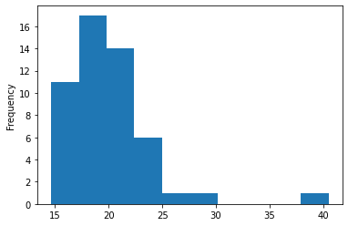

```python
(results_df['travel_time'].astype('timedelta64[s]') / 60).plot.hist()
```

We did the same with average speed.

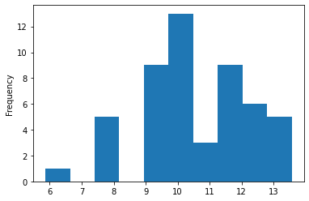

```python
results_df['mean_speed'].plot.hist()
```

We repeated this method of analysis with a variety of start and end locations, on both the Singapore and Jakarta dataset. We also tried to conduct separate analysis on the Jakarta dataset based on whether the trip was by car or motorcycle.

### 4. Conclusion

We have collated some of the outliers which took a longer time or took an odd route into our presentation.

Here are our findings:

- In both Jakarta & Singapore, our analysis of selected start points and end points shows that drivers can take varying routes, which may lead to inconsistent trip times, which can cause perception of delays/late driver arrival
- Often, odd or longer routes are taken during peak hours
- It is possible that Grab’s route recommendation system will recommend suboptimal routes during peak hours
- Alternative routes might have been suggested with the intention of avoiding congested roads, but eventually a route that takes a longer time overall was taken

However, we acknowledge the following limitations:

- We are not sure if these drivers selected the routes based on information from the Grab app or if they deviated and took a different route by themselves
- It is possible that these longer trips/odd routes were due to multiple drop-off points or Grab Hitch rides

Nevertheless, these are potential recommendations which can be used to alleviate perception of long travel times:

- During peak hours, detouring from congested roads may not save time, Grab may recommend drivers to continue using the route suggested on non-peak hours
- For Jakarta, travelling by car in the city area is slower relative to travelling in residential areas, whereas motorcycle average speeds are consistent regardless of areas, Grab may recommend customers to travel by motorcycle in city area for faster transport